# Client Report - What’s in a Name?

Course DS 250

Author

Nathan Luckock

```python
import pandas as pd
import numpy as np
from lets_plot import *
import matplotlib.pyplot as plt
import seaborn as sns

LetsPlot.setup_html(isolated_frame=True)
```

## Project Notes

**For Project 1 the answer to each question should include a chart **and** a written response. The years labels on your charts should not include a comma. At least **two** of your charts must include reference marks.**

```python
# Learn morea about Code Cells: https://quarto.org/docs/reference/cells/cells-jupyter.html

# Include and execute your code here
df = pd.read_csv("https://github.com/byuidatascience/data4names/raw/master/data-raw/names_year/names_year.csv")
```

## QUESTION|TASK 1

**How does your name at your birth year compare to its use historically?**

My name, Nathan, saw a steady rise in popularity throughout the mid 1900s and peaked right around 2005, the year I was born. Historically, it wasn’t very common in the early 1900s, but it became much more popular by the late 20th century. The trend shows that I was born at the height of the name’s popularity.

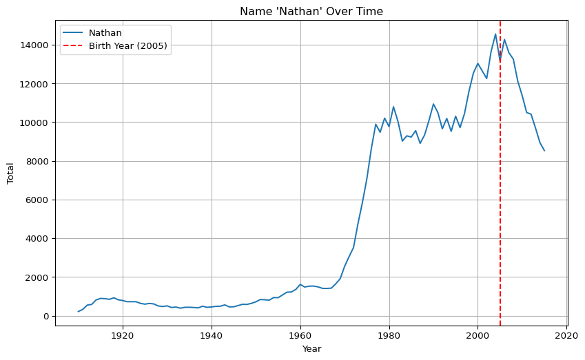

```python
my_name = df[df['name'] == "Nathan"]

plt.figure(figsize=(10, 6))
plt.plot(my_name["year"], my_name["Total"], label="Nathan")
plt.axvline(2005, color='red', linestyle='--', label="Birth Year (2005)")
plt.title("Name 'Nathan' Over Time")
plt.xlabel("Year")
plt.ylabel("Total")
plt.legend()
plt.grid(True)
plt.show()
```

## QUESTION|TASK 2

**If you talked to someone named Brittany on the phone, what is your guess of his or her age? What ages would you not guess?**

If I talked to someone named Brittany on the phone, I would guess they were born between 1985 and 1995. I would not guess they were younger than 20 or older than 45, since the name was rarely used outside that time window.

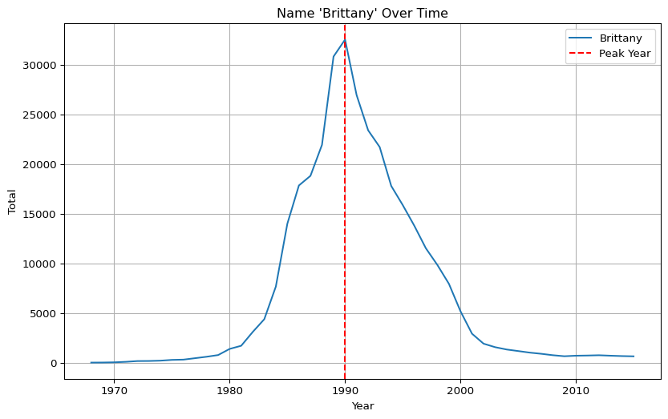

```python
britt = df[df["name"] == "Brittany"]

plt.figure(figsize=(10, 6))
plt.plot(britt["year"], britt["Total"], label="Brittany")
plt.axvline(britt["year"][britt["Total"].idxmax()], color='red', linestyle='--', label="Peak Year")
plt.title("Name 'Brittany' Over Time")
plt.xlabel("Year")
plt.ylabel("Total")
plt.legend()
plt.grid(True)
plt.show()
```

## QUESTION|TASK 3

**Mary, Martha, Peter, and Paul are all Christian names. From 1920 - 2000, compare the name usage of each of the four names in a single chart. What trends do you notice?**

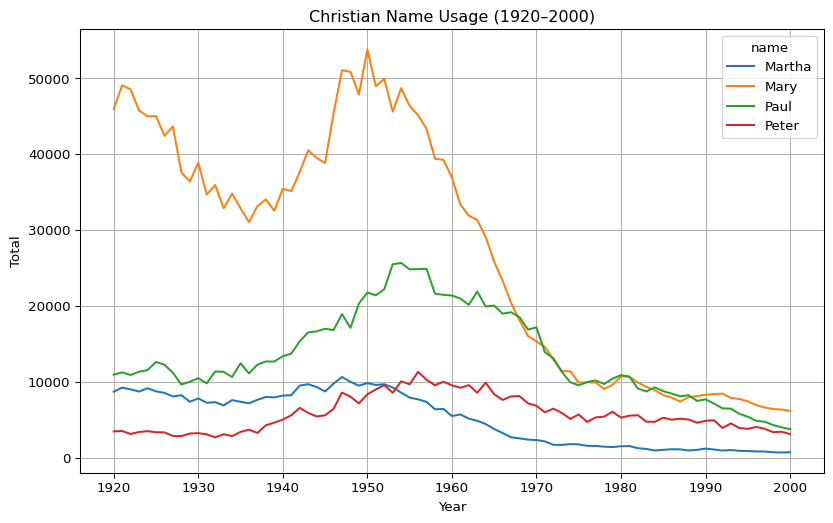

```python
names = ["Mary", "Martha", "Peter", "Paul"]
subset = df[(df["name"].isin(names)) & (df["year"] >= 1920) & (df["year"] <= 2000)]

plt.figure(figsize=(10, 6))
sns.lineplot(data=subset, x="year", y="Total", hue="name")
plt.title("Christian Name Usage (1920–2000)")
plt.xlabel("Year")
plt.ylabel("Total")
plt.grid(True)
plt.show()
```

## QUESTION|TASK 4

**Think of a unique name from a famous movie. Plot the usage of that name and see how changes line up with the movie release. Does it look like the movie had an effect on usage?**

The name Trinity became more popular after the movie The Matrix came out in 1999. It grew a lot in the early 2000s and peaked around 2005. Before the movie, it wasn’t used much. The chart shows that the movie likely had a big effect on how often the name was chosen.

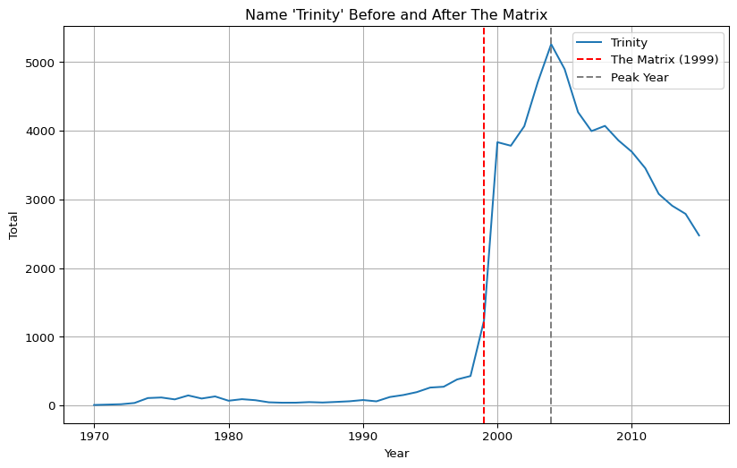

```python
trinity = df[df["name"] == "Trinity"]

plt.figure(figsize=(10, 6))
plt.plot(trinity["year"], trinity["Total"], label="Trinity")
plt.axvline(1999, color='red', linestyle='--', label="The Matrix (1999)")
plt.axvline(trinity["year"][trinity["Total"].idxmax()], color='gray', linestyle='--', label="Peak Year")
plt.title("Name 'Trinity' Before and After The Matrix")
plt.xlabel("Year")
plt.ylabel("Total")
plt.legend()
plt.grid(True)
plt.show()
```

## STRETCH QUESTION|TASK 1

**Reproduce the chart Elliot using the data from the `names_year.csv` file.**

Stretch challenge completed!

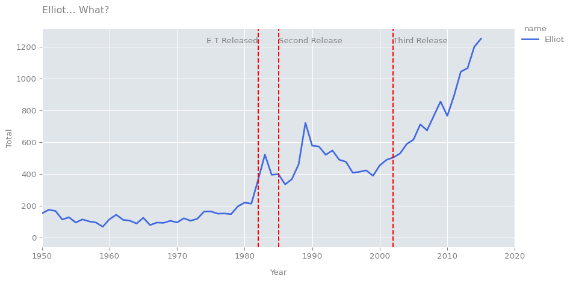

```python
import matplotlib.pyplot as plt

elliot = df[df["name"] == "Elliot"]
years = elliot["year"]
values = elliot["Total"]

fig, ax = plt.subplots(figsize=(10, 5))
fig.patch.set_facecolor('white')
ax.set_facecolor('#e0e5ea')

ax.plot(years, values, color='royalblue', linewidth=2)

for x in (1982, 1985, 2002):
    ax.axvline(x, color='red', linestyle='--')

max_y = values.max()
for x, txt, ha in [(1982, "E.T Released", 'right'),
                   (1985, "Second Release", 'left'),
                   (2002, "Third Release", 'left')]:
    ax.text(x, max_y * 0.97, txt, color='gray', ha=ha, va='bottom')

for spine in ax.spines.values():
    spine.set_visible(False)

xticks = list(range(1950, 2021, 10))
yticks = list(range(0, 1201, 200))
ax.set_xticks(xticks)
ax.set_yticks(yticks)

tick_spacing = yticks[1] - yticks[0]
bottom_pad = tick_spacing * 0.30  # =10

ax.set_ylim(-bottom_pad, max_y * 1.05)
ax.set_xlim(1950, 2020)

ax.grid(which='major', color='white')

ax.tick_params(colors='gray')
ax.xaxis.label.set_color('gray')
ax.yaxis.label.set_color('gray')

ax.set_title("Elliot… What?", loc='left', color='gray', pad=20)

ax.legend(["Elliot"], loc="upper left", bbox_to_anchor=(1,1),
          frameon=False, labelcolor='gray')
ax.set_ylabel("Total", labelpad=20, color='gray', rotation=90, ha='center', va='bottom')
ax.text(1.02, .99, "name", transform=ax.transAxes, color='gray', fontsize=10, ha='left')


ax.yaxis.set_label_coords(-0.06, 0.5)
ax.set_xlabel("Year", labelpad=10, color='gray')

plt.tight_layout()
plt.show()
```